# Are Leveraged ETFs Worth It For Young Investor’s?

Trey Davidson

2025-01-13

#### Introduction

I am a young investor who is currently interested in saving for retirement. As a young investor traditional investment advise would say I can afford to take on risk as I have a long time horizon to make up losses through income generation and other methods. If I lose all of my investment at the age of 30, I am essentially equal in position to someone who starts saving money in there 30’s. [Considering the fact that 31 is the average age to start saving for retirement I wouldn’t be alone](https://news.nationwide.com/americas-retirement-voice-reveals-how-much-it-costs-to-delay-retirement/).

#### The Decesion

Since, I am less concerned about risk I have two choices when it comes to magnifying gains, I can either concentrate a portfolio or take on leverage. The issue with concentration is that many biases can come at play that make stock picking hard unlike leverage, which would allow me to keep the diversity of the S&P 500 or QQQ, while also magnifying returns.

Here are some leveraged ETF’s that may be included and there relevant websites for any additional information you may be looking for.

[SPY](https://www.ssga.com/us/en/intermediary/etfs/spdr-sp-500-etf-trust-spy) - Top 500 Companies US  
[QQQ](https://www.invesco.com/qqq-etf/en/home.html) - Top 100 NASDAQ companies tech weighted heavily  
[UPRO](https://www.proshares.com/our-etfs/leveraged-and-inverse/upro) - 3x Leveraged S&P 500  
[TQQQ](https://www.proshares.com/our-etfs/leveraged-and-inverse/tqqq) - 3x Leveraged QQQ  
[QLD](https://www.proshares.com/our-etfs/leveraged-and-inverse/qld) - 2x Leveraged QQQ  
[SSO](https://www.proshares.com/our-etfs/leveraged-and-inverse/sso) - 3x Leveraged S&P 500

# Comapring QQQ to QLD

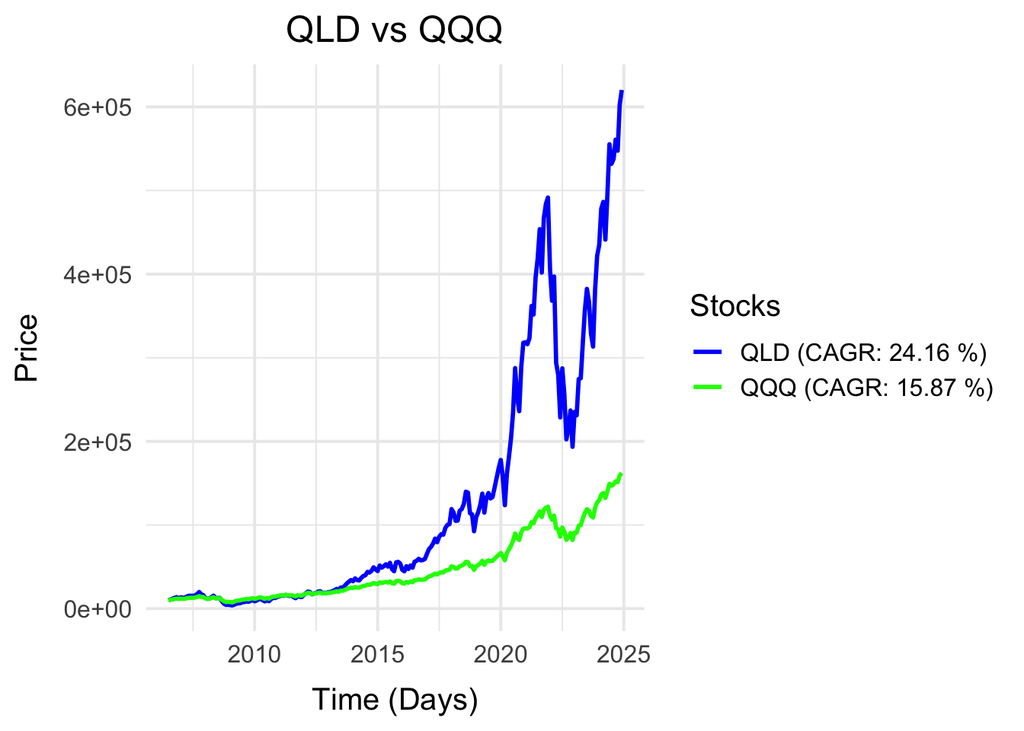

In our initial backtest, QLD (the 2x leveraged QQQ) significantly outperforms QQQ. However, before drawing any conclusions, it is crucial to assess whether these observed differences could be attributed to random chance. To determine the appropriate statistical test, we need to address two key questions:

1. Are the monthly returns independent?
2. Are the monthly returns normally distributed?

Regarding question 1, a typical approach would be to use a chi-square test to examine the independence of the returns. However, since QLD is a leveraged derivative of QQQ, we acknowledge that QLD’s performance is inherently dependent on QQQ’s returns. As such, we will account for this relationship in our analysis.

For question 2, it is important to first visualize the distribution of returns. A histogram can reveal the shape and skewness of the returns, providing insights into their distribution.

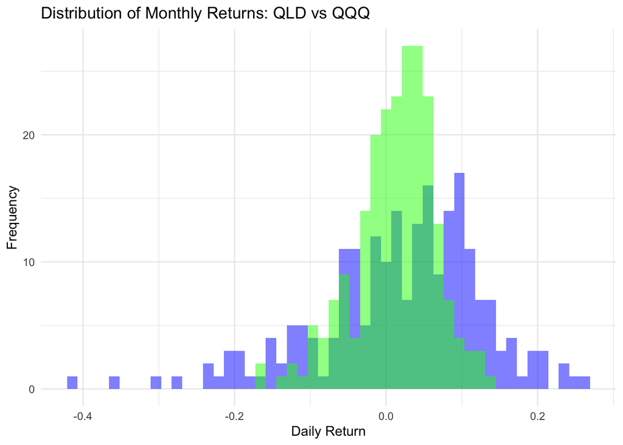

```
## QLD Test - W: 0.9645047 p-value: 2.391497e-05
```

```
## QQQ Test - W: 0.972952 p-value: 0.00029371
```

The results of the Shapiro-Wilk test confirm our visual analysis, indicating that neither of these distributions is normally distributed. Therefore, we cannot use the t-test, as it assumes normality. Instead, we will use the Wilcoxon test, which does not assume normality or independence of observations

```
## Test - W: 27551.5 p-value: 0.03141331
```

This happens due to the way percentages stack on top of each other. For example, lets compare two stocks. One that goes up by 50% and then drops 15%, and a stock that goes up 10%.

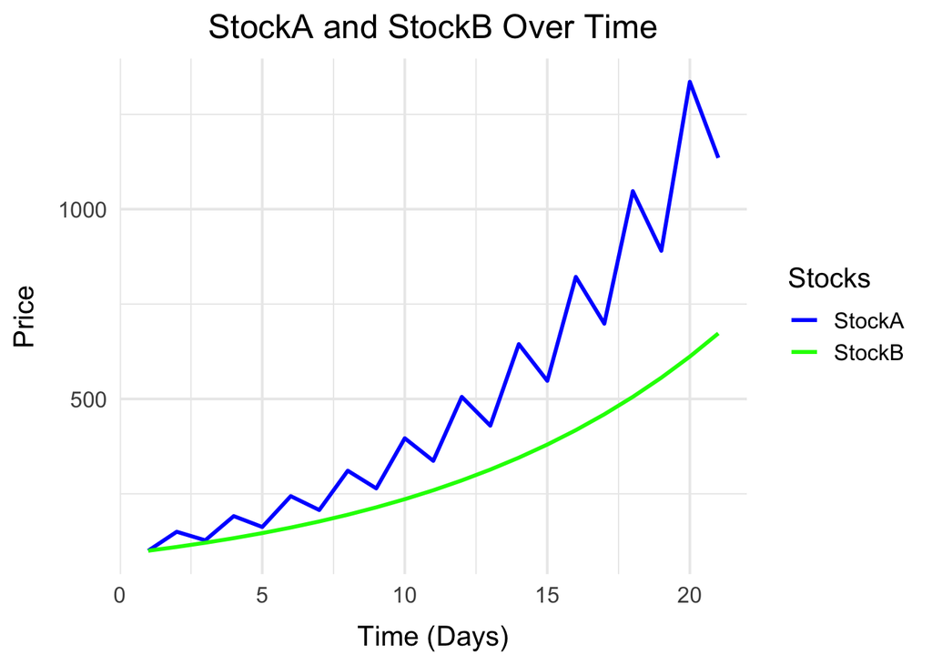

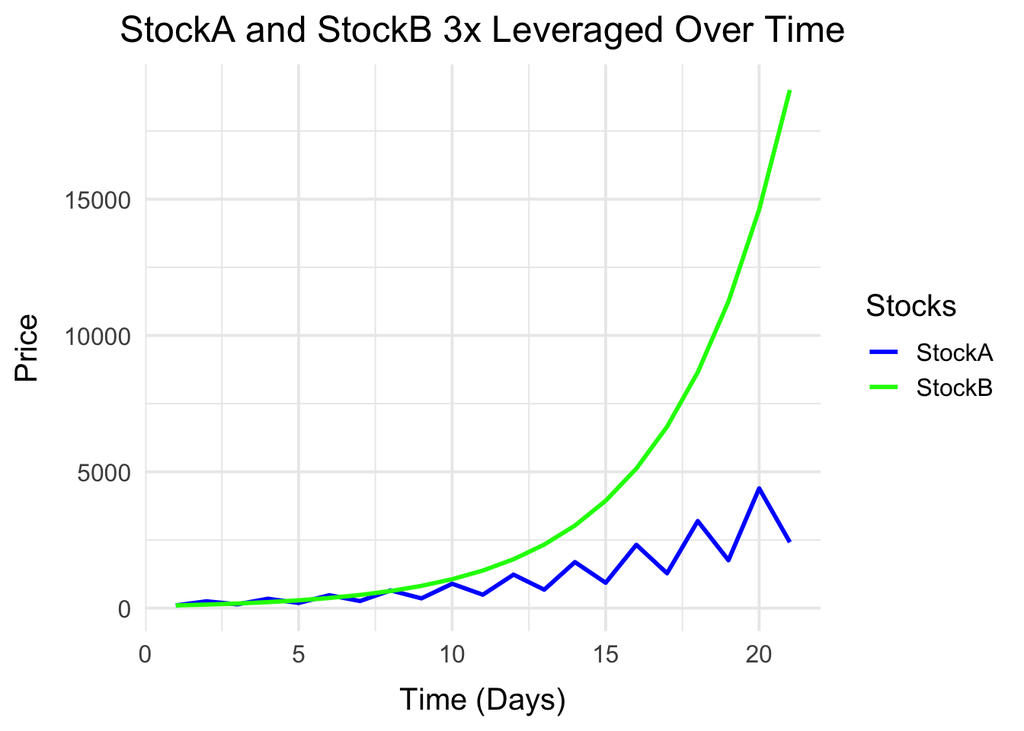

Upon simulating the performance of these stocks, it becomes clear that while Stock A outperformed Stock B in absolute terms, the leveraged derivative of Stock B exhibited significantly superior performance. The simplest expiation why is that a 50% loss requires a 100% gain to make up, meanwhile a 50% gain only takes a 33.333% loss to destroy. This simple concept is extremely important when dealing with leveraged high risk investments.

Let’s look at how this simple relationship plays out in our simulation. Stock A normally would have a cycle of a 50% gain followed by a 15% loss, which would result in an approximate 12.19%, which is better then Stock B, which only had a 10% compounding result. This means that we would expect that Stock A would have a 36.57% aproxmit compounding gain, while Stock B would only have 30%, but in reality a 150% gain and 45% loss only results in an approximate 17.26% compounding gain. This means that growth isn’t the only thing that matters with leveraged products, but by how much it grows is also important. This is one of the main reasons why all leveraged products will say that they are only there for day traders as in the long run they will not have 3x returns. Now there are some advantages to this model, which is that circuit breakers will prevent the stock from ever hitting that 33.333% loss that is required to take our position to 0. Meanwhile, if we took leverage over a longer period lets say 6 months. If SPY fell by 33.333% over those 3 months our position would go to 0.

Now the worst part about this day to day resetting model isn’t that losses stack up as if SPY falls by 20%, you already are expecting to lose a lot of money, but what happens during flat markets.

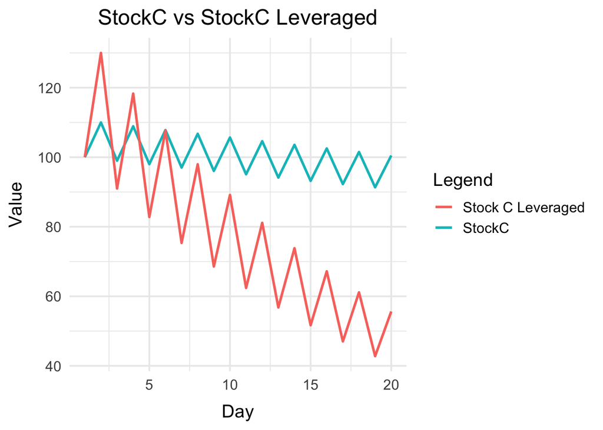

# SPXTR vs SPXL

Let’s compare the total return of the S&P 500 to the 3x leveraged S&P 500 daily. Since inception, which was post 2008 SPY has not had much volatility to the point where shorting the VIX was a popular strategy all the way up until Volmageddon, which was when several inverse VIX ETPs collapsed in 2018.

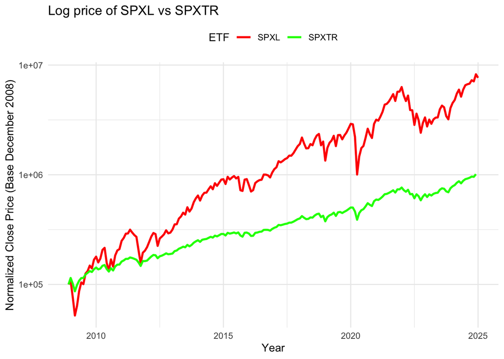

If you would have invested 100K into SPXL at inception, you would have quickly second guessed your option as it collapsed almost to 50K, but if you would have stuck around you would have 7,654,218, meanwhile if you would have just invested in the S&P 500 you would have had 1,011,590.

As I stated before the simulation though, this happened during a time when shorting VIX was a popular stratgey. Now to see if its better then the S&P 500 it would be nice to stretch our simulation very far back as this would allow it to play over different periods. Luckily with Yahoo Finances Historical S&P 500, we can simulate from before the great depression.

# The backtest of the centry

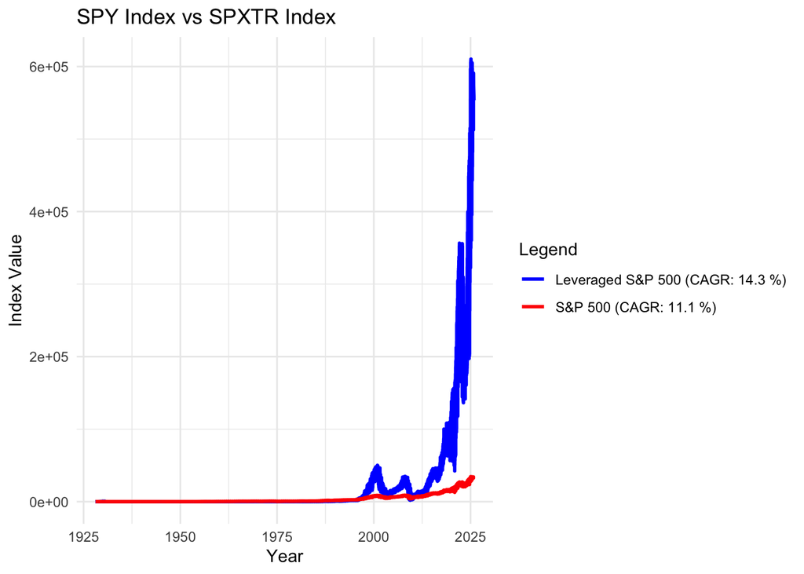

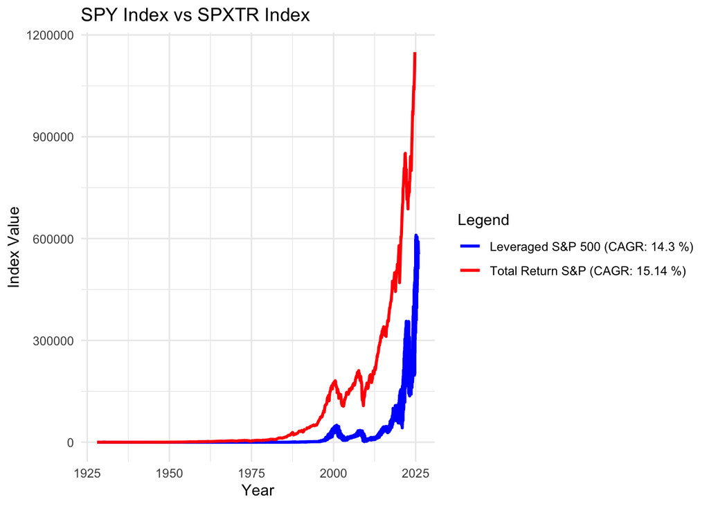

# What if we pick something with low dividends

Our last simulation was not very good for leveraged ETFs, so instead lets look at QQQ. QQQ is the top 100 companies listed on the NASDAQ, which is tech heavy. Its dividend yield is about 0.5% where SPY is about 1.21%.

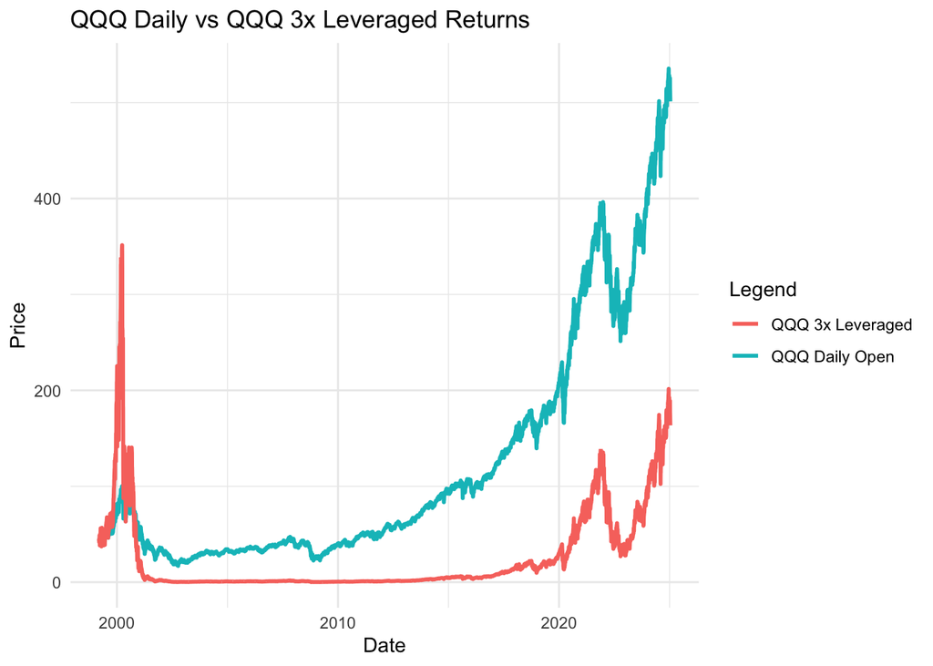

In this instance, the 3x leverage performance does well, but then collpases during the .com buble, and is never able to recover. This raises the question of whether lower leverage could have better retruns then higher leverage as you lose less capital during bad years.

Let’s compare a QQQ to leveraged ETFs that leverage between 1-5.

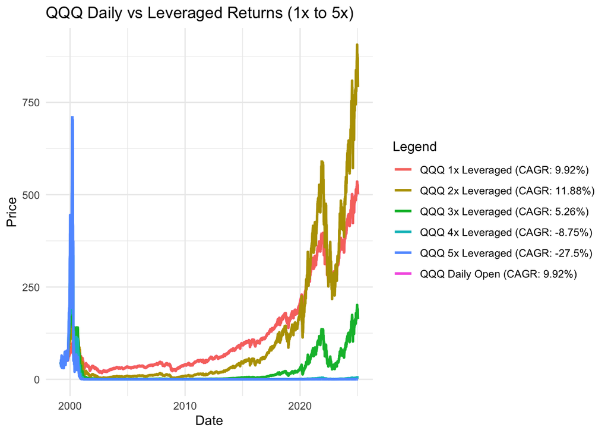

The 2x leverage etf does the best followed by the 1x leverage, then the 3x leverage, and the rest finish near 0. Now you may be wondering what happens if we do this with SPY.

```
## P-value: 0.0006221874
```

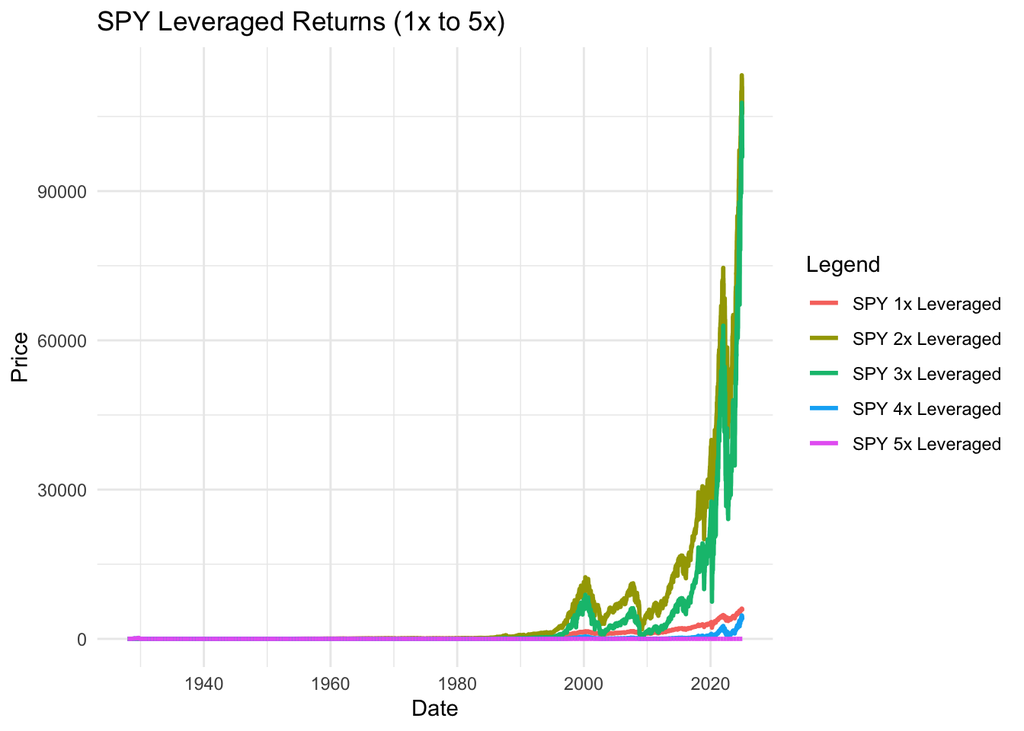

The 2x leveraged ETF slightly outperforms the 3x leveraged ETF. To verify whether the difference in returns is statistically significant, we performed a Wilcoxon test. The test yielded a very small p-value, indicating that the likelihood of the observed difference being due to random chance is extremely low. Therefore, it is highly probable that the returns are genuinely different.

# Conclusion